# check-df-again

Patricia Zito

2023-05-03

As it turns out I forgot to add my outgroups. So I’m making this file to both re-check my database in a new folder, add all paralogs, and remove NHE sequences.

# Check that I have all the outgroup paralogs

I’ll be checking this by comparing the protein accession numbers that show up on dataset (this comes from a blast search using EaffNHA7 as a query) and I’ll compare it with the results from the remote blast searches (using the first protein accession number of each species as the query).

```r
library(dplyr)
library(seqinr)
library(Biostrings)
library(ape)
setwd("/Users/pzito/Desktop/botany563-final/data/orthologs/CURATION4-add-outgroups")
outgroups <- read.csv("outgroups-filtered.csv") # Eaff as the
as_tibble(outgroups)
```

```
## # A tibble: 12 × 12
##        X species               protein.accession protein.sequence protein.length
##    <int> <chr>                 <chr>             <chr>                     <int>
##  1     0 Hypsibius exemplaris  OQV21679.1        "msrprlsqasstgl…            661
##  2     1 Ramazzottius varieor… GAU88015.1        "mkehpgikkigskv…            551
##  3     2 Hypsibius exemplaris  OWA52319.1        "mpapgdhlrkissr…            538
##  4     3 Hypsibius exemplaris  OQV23204.1        "mfetlqylhlsnte…            629
##  5     4 Ramazzottius varieor… GAV01214.1        "matksefvgksqpi…            619
##  6     5 Ramazzottius varieor… GAU92661.1        "mnqrrasegnkylc…            591
##  7     6 Hypsibius exemplaris  OQV26214.1        "mlpniylpkerkan…            669
##  8     7 Ramazzottius varieor… GAV01898.1        "mvgmssafdppnek…            533
##  9     8 Hypsibius exemplaris  OQV23203.1        "mflnsngkhppavi…            527
## 10     9 Ramazzottius varieor… GAV01215.1        "matksefvgksqpi…            338
## 11    10 Ramazzottius varieor… GAV01897.1        "mepagldfssisca…            428
## 12    11 Ramazzottius varieor… GAU88122.1        "MLQYIRKKESQFLY…            519
## # ℹ 7 more variables: project.accession <chr>, sequencing.technology <chr>,
## #   assembly.name <chr>, assembly.status <chr>, scaffold.N50 <int>,
## #   coverage <int>, scaffold.count <int>
```

```r
# these are the proteins that showed up on the EaffNHA7 blast search
outgroups%>%filter(species == "Hypsibius exemplaris")%>%select(protein.accession)
```

```
##   protein.accession
## 1        OQV21679.1
## 2        OWA52319.1
## 3        OQV23204.1
## 4        OQV26214.1
## 5        OQV23203.1
```

```r
outgroups%>%filter(species == "Ramazzottius varieornatus")%>%select(protein.accession)
```

```
##   protein.accession
## 1        GAU88015.1
## 2        GAV01214.1
## 3        GAU92661.1
## 4        GAV01898.1
## 5        GAV01215.1
## 6        GAV01897.1
## 7        GAU88122.1
```

checking the .blastn results, I seem to have gotten all the Hypsibius paralogs. In fact, the last one is repeated twice. So I’ll have to remove that. Removed manually. The Ramazzottius sequences are a little weird. I don’t know why, but some of them have different initials, even though they have the same bioproject. Oh well. I’ll take it. They have everything but this protein: GAU88122.1.

# Remove NHEs from outgroup df

```r
# remove NHEs again
remove_NHE <- function(df){
  gap_open <- -10
  gap_extent <- -1
  index_list <- c()

  DmelNHE3 <- readAAStringSet(file = "DmelNHE3_prot.fasta")
  DmelNHA2 <- readAAStringSet(file = "DmelNHA2_prot.fasta")
  GAU88122.1 <- readAAStringSet(file = "GAU88122.1.fasta")
  seq_name = df$protein.accession
  sequence = df$protein.sequence

  for(i in 1:length(sequence)){
    seq <- AAString(toupper(sequence[i]))
    NHE_score <- pairwiseAlignment(DmelNHE3, seq, type = "global", substitutionMatrix = "BLOSUM50", gapOpening = gap_open, gapExtension = gap_extent, scoreOnly = TRUE)
    NHA_score <- pairwiseAlignment(DmelNHA2, seq, type = "global", substitutionMatrix = "BLOSUM50", gapOpening = gap_open, gapExtension = gap_extent, scoreOnly = TRUE)
    if(NHE_score >= NHA_score){
      index_list <- append(index_list, i)
    } else if (NHE_score <= NHA_score & NHA_score < 0){
      paste(seq_name[i], "passed the test, but it still did not align well with NHA")
    }
  }
  df2 <- df[-which(df$protein.accession %in% seq_name[index_list]),]
  print(df2)
  return(df2)
}

 outgroups_cleaned <- remove_NHE(outgroups)

# then manually check GAU88122.1
DmelNHE3 <- readAAStringSet(file = "DmelNHE3_prot.fasta")
DmelNHA2 <- readAAStringSet(file = "DmelNHA2_prot.fasta")
GAU88122.1 <- readAAStringSet(file = "GAU88122.1.fasta")
NHE_score <- pairwiseAlignment(DmelNHE3, GAU88122.1, type = "global", substitutionMatrix = "BLOSUM50", gapOpening = -10, gapExtension = -1, scoreOnly = TRUE)
NHA_score <- pairwiseAlignment(DmelNHA2, GAU88122.1, type = "global", substitutionMatrix = "BLOSUM50", gapOpening = -10, gapExtension = -1, scoreOnly = TRUE)
NHE_score >= NHA_score
```

[output not shown]

ok I seem to not have gotten any NHEs? Weird, but ok. For now I’ll just add these to both my more and less stringent databases manually (column number doesn’t match and for the most stringent I have to also check on ncbi the conserved domain and get the cds sequence, so it’s not really worth trying to do this on R). done.

# decide which of the outgroup paralog sequences should be the most defined outgroup

ok I added back GAU88122.1 into the outgroup-filtered.csv. And I’ll now write it as a fasta file.

```r
# handy dandy function
write_fasta <- function(out_name, df){
  sink(out_name)
  for (i in 1:nrow(df)){
    cat(df$fasta.names[i])
    cat("\n")
    cat(df$protein.sequence[i])
    cat("\n")
  }
  sink()
}
```

```r
fasta.names <- c()
for(i in 1:nrow(outgroups)){
  species.name <- str_replace(outgroups[i, "species"], " ", "-")
  partial.name <- paste(species.name, outgroups[i, "protein.accession"], sep = "-")
  fasta.name <- paste(">", partial.name, sep = "")
  print(fasta.name)
  fasta.names <- append(fasta.names, fasta.name)
}
outgroups <- cbind(outgroups, fasta.names)

write_fasta("outgroups.fasta", outgroups)
```

Aligned using clustalw.

```r
out_aln <- read.alignment("outgroups.aln", format = "clustal")
out_aln$seq
```

```
## [[1]]
## [1] "----------------------------------------------------------mfetlqylhlsntelrpahwyegnhkypegntaessslshrvlrqftstlietheiqrmlpksngnpqptviamqp---idwrr-tnvdngqrearnggfvrrwtnalmlkn-sppienptcvqrfrrallcpphgslaynltkiiaiialflafiailkaealpggnfwgll…--ttsltmqilqapieivigvsyglatgvlfwffphnghpsksayrfiillgagltavfg…
##
## [[2]]
## [1] "--------------------------------------------------------------------------------------------------------------------mflnsngkhppaviemqptepidasr-vdaksdqqaarngsfskrwtsavmekn-trpiehltgvqrfrrallcpphgalaynltkiiaiialfsalvailkaeafpggnlwallvvticamigeeiatklrlpgllgmliaglllqnvpgirvatsitpewssslrtvalvvill…
##
## [[3]]
## [1] "----------------------------------------------------------matksefvgksqpivr-----dgdgshstritsngspk---------sslkeaiemgrlddrkdsredishgqvssteytnghastgpgmsspqttrlafirrlqna…--ttsltmqilqapieitialvygsivgyslwyfpdythpsrqayrfvlllaagmtavfggntlkysgagplacvitaftagyrwriq-daaahkatatdmsklwryfqpvlfglvgasvslsrik…
##
## [[4]]
## [1] "----------------------------------------------------------matksefvgksqpivr-----dgdgshstritsngspk---------sslkeaiemgrlddrkdsredishgqvssteytnghastgpgmsspqttrlafirrlqna…--ts------------------------------------------------------------------------tayvarr-------------------------------------------…
##
## [[5]]
## [1] "------------------------------------------------------------------------------------------------------------------------------------------------------mkehpg--ikkigskvlled-nplpvnpsfsrrlwyhflcpphsylaylltrgmvclliwltafavfkqdalpggnvfalf…-lnwkeklftaiawvpkatvqaalgsvaldiaretnal----------pevidlg-----…
##
## [[6]]
## [1] "-------------------------------------------------------------------------------------------------------------------------------------------------------mpapgdhlrkissrvllkh-nplpekptfrqrlwhkclcpphtalgnllsralicllvwlagfslvredalpggnvfalf…-mnlkeklftaiawipkatvqaalgsialtlareknss----------aemillg-----…
##
## [[7]]
## [1] "-----------msrprlsqasstglpqwrqsrvgslsgtnhliptrfifekiesthsssssnnnnnnqhsdtggtgydvressesgshnnkpsstvvyrstfqifvsaddpdyaapegldgiavlgrrgiklnimgheddeggegessrsicarlqacldrskrsvlhkh-ntlpddptlpqriwylllcpphgpcavfltkiligllvwltllsllkedalpggnvfalv…-gaalwfnilqgplemlmgltygifigfifwylphrrhddlstlrflfllcgglvgvfgs…
##
## [[8]]
## [1] "----------------------------------------------------------------------------------------------------------------------------------------------------------mlqyirkkesqflyek-nilpehptcaervyhaflcpphgrvadiivklllgllawltalsvfkddalpggnifall…--gsplwfqiiqgpleilmglsfglvigilfwyfperqnadlsvlrfvflflgelvavfg…
##
## [[9]]
## [1] "-------------------------------------------------------------------mnqrras------------------------------egnk--ylcircadptckneqcqkpgrlttstfegvgfmg---------kvkkavqevlrpalksshtqpspdaplaqrlkydlllpptgivsrlvtlallafmiwaal…--ngslafniaaifltfivgfafgifvgwilvyfpsgdddtasifrfvlllcsgalcifgskianlsgagaigalivp…
##
## [[10]]
## [1] "mlpniylpkerkanptvpfqpqhhltvtsvvtvssmphhdkitfsphrpgqparlepsasqasmvsttnervvn------------------------------vsdrrsltaapctdyackheqcrlrneqrqrkwysgcwng---------ltrkwmr-lfqpvmksshpapgpsagwfrqvgyemmlpptgiaarlvtlamlaffiwaafwsvltkdm…--ngslafniaaapiqivvgigfgilvgwilvyfpsgddnaatifrfilllcsgvlcifgskianlsgag…
##
## [[11]]
## [1] "-------------------------------------------------------------------------------------------------------------mvgmssafdppnektslrlgeavaaddipavlpigpssqngrlsrispalhrllrplvks…--ngnlqfniaaifltfiagigfglfagwilthfpagdddwatifrfillvctgllcifgskavnlsgagalaalivpmvagqgwrrkgcsdslqeisvslktgwfifqpllfgligaavdv…
##
## [[12]]
## [1] "mepagldfssiscapvlkmsvdharcqqpvadinpesrcstislvpyrhiklfctaqpll…--ng--------------------------------------------------------------idggisiivivpqvs------------------------------------------------------------pmqlak-fvar-------------------------------------------------------------------------------…
```

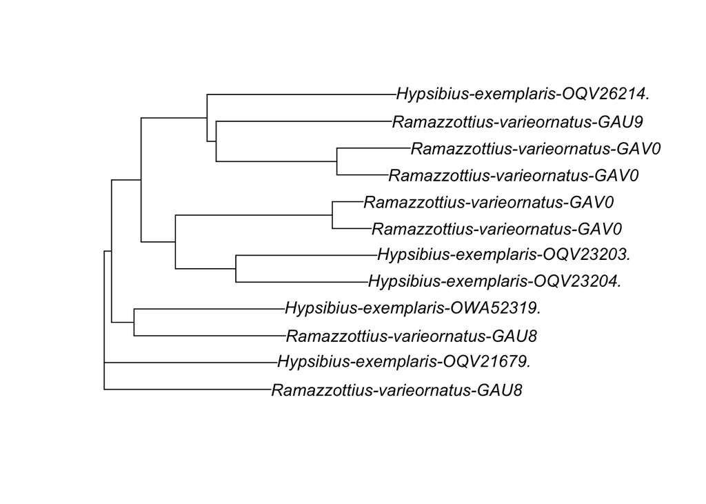

```r
dist_matrix <- dist.alignment(out_aln)
out_tree <- nj(dist_matrix)
plot.phylo(out_tree)
```

From this plot, it seems like it’s either OQV21679.1 or one of the GAU8 something.

```r
ultra_conserved <- read.csv("orthologs-filtered-CONSERVED+outgroups.csv")
as_tibble(ultra_conserved)
```

```
## # A tibble: 83 × 15
##    assembly.name assembly.status coverage project.accession protein.accession
##    <chr>         <chr>           <chr>    <chr>             <chr>
##  1 Ogib_1.0      Chromosome      80       PRJNA681589       KAG8183784.1
##  2 Ogib_1.1      Chromosome      80       PRJNA681590       KAG8183783.1
##  3 Ogib_1.2      Chromosome      80       PRJNA681591       KAG8186330.1
##  4 Tcal_SD_v2.1  Chromosome      180      PRJNA237968       TRY75264.1
##  5 SNU_Aamp_1    Scaffold        116      PRJNA549550       KAF0289584.1
##  6 CRF-TW_Dcit   Scaffold        98       PRJNA800468       KAI5736882.1
##  7 CRF-UY_Dcit   Scaffold        100      PRJNA800468       KAI5704272.1
##  8 CRF-UY_Dcit   Scaffold        100      PRJNA800468       KAI5704273.1
##  9 CRF-UY_Dcit   Scaffold        100      PRJNA800468       KAI5704902.1
## 10 CRF-CA_Dcit   Scaffold        119      PRJNA800468       KAI5742900.1
## # ℹ 73 more rows
## # ℹ 10 more variables: protein.length <int>, protein.sequence <chr>,
## #   scaffold.N50 <chr>, scaffold.count <chr>, sequencing.technology <chr>,
## #   species <chr>, fasta.names <chr>, type <chr>, cds.seq <chr>, comments <chr>
```

```r
ultra_conserved%>%filter(type == "tardigrade")%>%select(protein.accession)
```

```
##   protein.accession
## 1        OQV21679.1
## 2        GAU92661.1
## 3        OQV26214.1
## 4        GAV01898.1
## 5        GAV01897.1
```

It looks that on my ultra conserved database (this is after removing all sequences that don’t have the NA_H_exchanger CDD), only OQV21679.1 is present. So I’ll use that as my outgroup outgroup.

# checking ultra-conserved dataframe

```r
nrow(ultra_conserved) # number of sequences
```

```
## [1] 83
```

```r
table(ultra_conserved$type) # number of types
```

```
##
##     barnacle    cockroach      copepod         crab      diptera     ephemera
##            1            3            2            1            9            6
##    hemiptera  hymenoptera  lepidoptera       spider   tardigrade thysanoptera
##           10           12           27            3            5            1
##         tick
##            3
```

```r
length(unique(ultra_conserved$species)) # how many species
```

```
## [1] 35
```

```r
table(ultra_conserved$species) # how many paralogs per species
```

```
##
##     Acromyrmex echinatior   Amphibalanus amphitrite         Ampulex compressa
##                         1                         1                         2
##         Anopheles gambiae          Apolygus lucorum        Arctia plantaginis
##                         1                         2                         7
##              Brenthis ino        Ceratitis capitata           Cloeon dipterum
##                         5                         1                         5
##        Cotesia congregata         Cotesia glomerata      Dendrolimus kikuchii
##                         2                         1                         4
##          Diaphorina citri   Drosophila melanogaster         Eciton burchellii
##                         6                         2                         1
##           Ephemera danica        Eriocheir sinensis         Glossina fuscipes
##                         1                         1                         1
##      Helicoverpa armigera      Hypsibius exemplaris     Iphiclides podalirius
##                         4                         2                         6
##   Lepeophtheirus salmonis           Lucilia cuprina   Megalurothrips usitatus
##                         1                         2                         1
##           Nezara viridula       Oedothorax gibbosus            Ooceraea biroi
##                         2                         3                         2
##              Oppia Nitens     Periplaneta americana  Polypedilum vanderplanki
##                         3                         3                         2
## Ramazzottius varieornatus     Spodoptera littoralis Temnothorax longispinosus
##                         3                         1                         2
##    Tigriopus californicus          Vespula vulgaris
##                         1                         1
```

```r
mean(table(ultra_conserved$species)) # mean number of paralogs
```

```
## [1] 2.371429
```

```r
# all crustacean species
crustacean <- ultra_conserved%>%filter(type=="barnacle"|type=="copepod"|type=="shrimp")%>%select(species)
table(crustacean)
```

```
## species
## Amphibalanus amphitrite Lepeophtheirus salmonis  Tigriopus californicus
##                       1                       1                       1
```

```r
nrow(unique(crustacean))
```

```
## [1] 3
```

```r
# all chelicerate species
chelicerate <- ultra_conserved%>%filter(type=="spider"|type=="tick")%>%select(species)
table(chelicerate)
```

```
## species
## Oedothorax gibbosus        Oppia Nitens
##                   3                   3
```

```r
nrow(unique(chelicerate))
```

```
## [1] 2
```

```r
# all hexapod species
hexapod <- ultra_conserved%>%filter(type=="cockroach"|type=="diptera"|type=="ephemera"|type=="hemiptera"|type=="hymenoptera"|type=="lepidoptera"|type=="thysanoptera")%>%select(species)
table(hexapod)
```

```
## species
##     Acromyrmex echinatior         Ampulex compressa         Anopheles gambiae
##                         1                         2                         1
##          Apolygus lucorum        Arctia plantaginis              Brenthis ino
##                         2                         7                         5
##        Ceratitis capitata           Cloeon dipterum        Cotesia congregata
##                         1                         5                         2
##         Cotesia glomerata      Dendrolimus kikuchii          Diaphorina citri
##                         1                         4                         6
##   Drosophila melanogaster         Eciton burchellii           Ephemera danica
##                         2                         1                         1
##         Glossina fuscipes      Helicoverpa armigera     Iphiclides podalirius
##                         1                         4                         6
##           Lucilia cuprina   Megalurothrips usitatus           Nezara viridula
##                         2                         1                         2
##            Ooceraea biroi     Periplaneta americana  Polypedilum vanderplanki
##                         2                         3                         2
##     Spodoptera littoralis Temnothorax longispinosus          Vespula vulgaris
##                         1                         2                         1
```

```r
nrow(unique(hexapod))
```

```
## [1] 27
```

```r
table(ultra_conserved%>%filter(type=="cockroach"|type=="diptera"|type=="ephemera"|type=="hemiptera"|type=="hymenoptera"|type=="lepidoptera"|type=="thysanoptera")%>%distinct(species, type)%>%select(type))
```

```
## type
##    cockroach      diptera     ephemera    hemiptera  hymenoptera  lepidoptera
##            1            6            2            3            8            6
## thysanoptera
##            1
```

```r
# tardigrada
tardigrade <- ultra_conserved%>%filter(type == "tardigrade")%>%select(species)
table(tardigrade)
```

```
## species
##      Hypsibius exemplaris Ramazzottius varieornatus
##                         2                         3
```

```r
nrow(unique(tardigrade))
```

```
## [1] 2
```

```r
# diptera
unique(ultra_conserved%>%filter(type=="diptera")%>%select(species))
```

```
##                    species
## 1       Ceratitis capitata
## 2          Lucilia cuprina
## 4        Glossina fuscipes
## 5 Polypedilum vanderplanki
## 7  Drosophila melanogaster
## 9        Anopheles gambiae
```

```r
# ephemera
unique(ultra_conserved%>%filter(type=="ephemera")%>%select(species))
```

```
##           species
## 1 Ephemera danica
## 2 Cloeon dipterum
```

```r
# hemiptera
unique(ultra_conserved%>%filter(type == "hemiptera")%>%select(species))
```

```
##            species
## 1 Diaphorina citri
## 7  Nezara viridula
## 9 Apolygus lucorum
```

```r
# lepidoptera
unique(ultra_conserved%>%filter(type=="lepidoptera")%>%select(species))
```

```
##                  species
## 1   Dendrolimus kikuchii
## 5  Spodoptera littoralis
## 6     Arctia plantaginis
## 12          Brenthis ino
## 18  Helicoverpa armigera
## 22 Iphiclides podalirius
```

```r
# hymenoptera
unique(ultra_conserved%>%filter(type == "hymenoptera")%>%select(species))
```

```
##                      species
## 1  Temnothorax longispinosus
## 3          Eciton burchellii
## 4          Cotesia glomerata
## 5             Ooceraea biroi
## 7          Ampulex compressa
## 9         Cotesia congregata
## 11     Acromyrmex echinatior
## 12          Vespula vulgaris
```

# comments

```r
# which are mitochondrial
ultra_conserved[grep("mito", ultra_conserved$comments), ]%>%select(fasta.names)
```

```
##                    fasta.names
## 43 >T.longispinosus-TGZ49087.1
## 53    >A.echinatior-EGI60180.1
## 79    >H.exemplaris-OQV21679.1
```

```r
# which are chimeric
ultra_conserved[grep("chimeric", ultra_conserved$comments),]%>%select(fasta.names)
```

```
##                     fasta.names
## 9         >D.citri-KAI5704273.2
## 10        >D.citri-KAI5742900.1
## 54 >P.vanderplanki-KAG5676603.1
```

```r
# which are nha1
ultra_conserved[grep("nha1", ultra_conserved$comments),]%>%select(fasta.names)
```

```
## [1] fasta.names
## <0 rows> (or 0-length row.names)
```

```r
# which are nha2
ultra_conserved[grep("nha2", ultra_conserved$comments),]%>%select(fasta.names)
```

```
##                   fasta.names
## 5  >A.amphitrite-KAF0289584.1
## 40    >L.cuprina-KAI8116404.1
## 41    >L.cuprina-KAI8130912.2
## 47        >O.biroi-EZA57806.1
## 75 >E.sinensis-XP_050686642.1
## 76   >O.nitens-XP_054156261.1
## 77   >O.nitens-XP_054156387.1
## 78   >O.nitens-XP_054169184.1
```

# checking relaxed dataframe

```r
relaxed <- read.csv("orthologs-filtered-ALL+outgroups.csv")
nrow(relaxed) # number of sequences
```

```
## [1] 296
```

```r
length(unique(relaxed$species)) # how many species
```

```
## [1] 48
```

```r
table(relaxed$species) # how many paralogs per species
```

```
##
##     Acromyrmex charruanus     Acromyrmex echinatior         Acromyrmex heyeri
##                         1                         1                         2
##     Acromyrmex insinuator   Amphibalanus amphitrite         Ampulex compressa
##                         2                         2                         4
##          Apolygus lucorum        Arctia plantaginis         Blomia tropicalis
##                        42                         8                         2
##              Brenthis ino        Ceratitis capitata           Cloeon dipterum
##                        12                         3                        18
##        Cotesia congregata            Cotesia typhae          Cyprideis torosa
##                         4                         2                         1
##          Daphnia sinensis      Dendrolimus kikuchii  Dermatophagoides farinae
##                         1                         4                         1
##          Diaphorina citri         Eciton burchellii           Ephemera danica
##                         9                         1                         3
##     Halotydeus destructor      Helicoverpa armigera           Hyalella azteca
##                         2                         4                         8
##       Hyalomma marginatum      Hypsibius exemplaris            Idotea baltica
##                         1                         6                        19
##     Iphiclides podalirius   Lepeophtheirus salmonis           Lucilia cuprina
##                        20                         1                         4
##   Megalurothrips usitatus           Nezara viridula          Nymphon striatum
##                         3                        18                        31
##       Oedothorax gibbosus            Ooceraea biroi          Penaeus vannamei
##                         5                         2                         3
##     Periplaneta americana  Polypedilum vanderplanki Ramazzottius varieornatus
##                         7                         8                         7
##         Sarcoptes scabiei         Spodoptera exigua     Spodoptera frugiperda
##                         1                         3                         6
##     Spodoptera littoralis Temnothorax longispinosus    Tigriopus californicus
##                         4                         2                         2
##         Vespula germanica      Vespula pensylvanica          Vespula vulgaris
##                         2                         3                         1
```

```r
mean(table(relaxed$species)) # mean number of paralogs
```

```
## [1] 6.166667
```

# writing fasta files

```r
fasta.names <- c()
for(i in 1:nrow(relaxed)){
  species.name <- str_replace(relaxed[i, "species"], " ", "-")
  partial.name <- paste(species.name, relaxed[i, "protein.accession"], sep = "-")
  fasta.name <- paste(">", partial.name, sep = "")
  fasta.names <- append(fasta.names, fasta.name)
}
relaxed <- cbind(relaxed, fasta.names)

write_fasta("orthologs-filtered-ALL+outgroups.fasta", relaxed)
write_fasta("orthologs-filtered-CONSERVED+outgroups.fasta", ultra_conserved)
```

# taking out mitochondrial + chimeric sequences

```r
# find which rows are mitochondrial or chimeric
ultra_conserved[grep("mito", ultra_conserved$comments),] # 43, 53, 79
```

```
##    assembly.name assembly.status coverage project.accession protein.accession
## 43      tlon_1.0        Scaffold       85       PRJNA449506        TGZ49087.1
## 53     Aech_3.10        Scaffold      108        PRJNA62733        EGI60180.1
## 79       nHd_3.1        Scaffold      113       PRJNA360553        OQV21679.1
##    protein.length
## 43            617
## 53            501
## 79            661
##                                                                                                                                                                                                                                                                                                          …
## 43                                             mdiemgssrtnkpseelakrrvsisdqvmgidnpafehnrrisassehnsdqgrrksilh…
## 53                                                                                                                                                   MQSIFEDEPIASTSADAQANDEQIRENSMQIAEELDENEEHDENTCCHRATFCIPMLREILVTDVIFTFF\nDLQLTWADLFWFATVSGMVLLTWAVLYFLLNDMVLPGGSIFGLFVIVIFSYALGWTLAYIPRLHFPPIFG\nMLLA…
## 79 msrprlsqasstglpqwrqsrvgslsgtnhliptrfifekiesthsssssnnnnnnqhsd…
##    scaffold.N50 scaffold.count sequencing.technology                   species
## 43       514432           3987        IlluminaHiSeq; Temnothorax longispinosus
## 53      1110580           4339                 FALSE     Acromyrmex echinatior
## 79       342180           1421 PacBio;IlluminaHiSeq;      Hypsibius exemplaris
##                    fasta.names        type
## 43 >T.longispinosus-TGZ49087.1 hymenoptera
## 53    >A.echinatior-EGI60180.1 hymenoptera
## 79    >H.exemplaris-OQV21679.1  tardigrade
##                                                                                                                                                                                                                                                                                                          …
## 43                                                                                                                                         ATGGATATCGAGATGGGCAGCAGCAGAACGAATAAGCCCAGCGAGGAGTTGGCGAAGAGACGCGTGTCGA\nTCAGCGATCAGGTGATGGGAATCGATAATCCCGCCTTCGAGCATAACCGGCGCATCAGCGCGAGTTCGGA\nGCACAATTCTGATC…
## 53                                                                                                                                                                                                                                                                                                       …
## 79 ATGTCTCGGCCTCGGCTATCACAGGCCTCCTCCACCGGGCTGCCTCAGTGGCGGCAGTCCCGCGTCGGCA\nGTCTCAGCGGGACGAACCACCTCATACCCACGCGTTTCATCTTCGAGAAGATCGAGTCGACGCACTCGTC\nGTCGTCGTCCAACAACAACAACAACAACCAACATTCTGACACTGGCGGCACCGGATATGACGTCAGAGAA\nTCTTCAGAGAGCGGAAGTCACAATAATAAACCGTCGAGTACGGTGGTGTATCGATCGACTTTCCAGATCT\nTCGTCA…
##               comments
## 43 NHA2, mitochondrial
## 53 NHA2, mitochondrial
## 79       mitochondrial
```

```r
ultra_conserved[grep("chimeric", ultra_conserved$comments),] #9, 10, 54
```

```
##    assembly.name assembly.status coverage project.accession protein.accession
## 9    CRF-UY_Dcit        Scaffold      100       PRJNA800468      KAI5704902.1
## 10   CRF-CA_Dcit        Scaffold      119       PRJNA800468      KAI5742900.1
## 54        Pv_5.2      Chromosome      375       PRJNA660907      KAG5676603.1
##    protein.length
## 9             705
## 10            706
## 54            685
##                                                                                                                                                                                                                                                                                                          …
## 9   MASDVQRMAEICEKLSPKLSQKEPDILTNEPDHKKHPEHEHKKPSNELAEPKRKVSIASNAIQADIERNR\nKISAASLEAKRNMLMNGGEFNLSPPCNHHHHHNHYRASCDYGKSPLSVISNCDFNERRVSSISNDGIYNY\nENNQSQIERSWWFGLCIKCRQKEVGPGWEPQCWPKVCPHPFCPSYRHVARILALLIIGLLVWGVAYCIMG\nEDAAPGGQLFNIALLSICAHLGGWLFRMFTMPALVGMLLVGIVFENVGLISISKSYHEVESVLRKMALVV\nILTRA…
## 10 MTSMTCVRMAEICEKLSPKLSQKEPDILTNEPDHKKHPEHEHKKPSNELAEPKRKVSIASNAIQADIERN\nRKISAASLEAKRNMLMNGGEFNLSPPCNHHHHHNHYRASCDYGKSPLSVISNCDFNERRVSSISNDGIYN\nYENNQSQIERSWWFGLCIKCRQKEVGPGWEPQCWPKVCPHPFCPSYRHVARILALLIIGLLVWGVAYCIM\nGEDAAPGGQLFNIALLSICAHLGGWLFRMFTMPALVGMLLVGIVFENVGLISISKSYHEVESVLRKMALV\nVILTRA…
## 54                        MSSPHNNTSGDVSDTTSPVLSPTTEPKRKVSILTDPPSHLAYDNPAFEGPRRKISQQSDQSDNGAVRKKS\nILHNPLTPEQQQHALQQAEPVIQHQPLPTNYEKQNGDHHHHHTRERKQRKHSTTESLYSRHSRSSKKPAA\nESQLEHSWIYALCMRCRVQYNTPSWQPKHWEKVCPYPLCPSYRQFARLVSIILIGVLIYATTYAIIGKAA\nAPGGQLFSLVTLTIAANFGGWLMGLTTLPRLIGMLLTGILMQNIGAVNIDGISHV…
##    scaffold.N50 scaffold.count           sequencing.technology
## 9      22577667            383 PacBioSequelII;IlluminaNovaSeq;
## 10     22629945            346 PacBioSequelII;IlluminaNovaSeq;
## 54     35209052            387         IlluminaHiSeq;PacBioRS;
##                     species                  fasta.names      type
## 9          Diaphorina citri        >D.citri-KAI5704273.2 hemiptera
## 10         Diaphorina citri        >D.citri-KAI5742900.1 hemiptera
## 54 Polypedilum vanderplanki >P.vanderplanki-KAG5676603.1   diptera
##                                                                                                                                                                                                                                                                                                          …
## 9     ATGGCTTCAGACGTTCAGAGGATGGCCGAAATTTGCGAGAAGCTCAGCCCCAAGTTGAGTCAGAAGGAAC\nCTGACATACTTACCAATGAGCCGGATCACAAGAAACATCCAGAACACGAACACAAGAAACCATCCAATGA\nGCTCGCAGAACCCAAGAGGAAAGTGAGCATTGCCTCCAACGCCATCCAAGCAGATATCGAGAGGAATAGG\nAAGATCAGTGCAGCCTCTCTGGAAGCCAAGAGGAATATGCTGATGAATGGAGGAGAGTTCAATTTGAGCC\nCCC…
## 10 ATGACTTCAATGACCTGCGTGAGGATGGCCGAAATTTGCGAGAAACTCAGTCCCAAGTTGAGTCAGAAGG\nAACCTGACATACTTACCAATGAGCCGGATCACAAGAAACATCCAGAACACGAACACAAGAAACCATCCAA\nTGAGCTCGCAGAACCCAAGAGGAAAGTGAGCATTGCCTCCAACGCCATCCAAGCAGATATCGAGAGGAAT\nAGGAAGATCAGTGCAGCCTCTCTGGAAGCCAAGAGGAATATGCTGATGAATGGAGGAGAGTTCAATTTGA\nGCCCCC…
## 54                                                                  ATGAGTTCGCCACATAATAATACATCAGGCGATGTTTCGGATACGACTTCTCCAGTATTAAGTCCAACAA\nCTGAACCAAAACGAAAAGTTTCTATACTCACAGATCCACCGTCACATTTAGCTTATGACAATCCTGCATT\nTGAAGGTCCTCGACGGAAAATTTCTCAGCAATCTGATCAATCAGATAATGGAGCGGTTAGAAAGAAAAGT\nATTTTACACAATC…
##                               comments
## 9  maybe chimeric gene, NHA + PHA03292
## 10 maybe chimeric gene, NHA + PHA03292
## 54  maybe chimeric, NHA + PVAND_006426
```

```r
mega_conserved <- ultra_conserved%>%
  filter(!row_number() %in% c(43, 53, 79, 9, 10, 54))

# check that it worked
dim(ultra_conserved)
```

```
## [1] 83 15
```

```r
dim(mega_conserved)
```

```
## [1] 77 15
```

```r
mega_conserved[grep("mito", mega_conserved$comments),] # ok looks good
```

```
##  [1] assembly.name         assembly.status       coverage
##  [4] project.accession     protein.accession     protein.length
##  [7] protein.sequence      scaffold.N50          scaffold.count
## [10] sequencing.technology species               fasta.names
## [13] type                  cds.seq               comments
## <0 rows> (or 0-length row.names)
```

```r
mega_conserved[grep("chimeric", mega_conserved$comments),] # yep
```

```
##  [1] assembly.name         assembly.status       coverage
##  [4] project.accession     protein.accession     protein.length
##  [7] protein.sequence      scaffold.N50          scaffold.count
## [10] sequencing.technology species               fasta.names
## [13] type                  cds.seq               comments
## <0 rows> (or 0-length row.names)
```

```r
# new information about this database:
length(unique(mega_conserved$species)) # how many species
```

```
## [1] 34
```

```r
table(mega_conserved$species) # how many paralogs per species
```

```
##
##   Amphibalanus amphitrite         Ampulex compressa         Anopheles gambiae
##                         1                         2                         1
##          Apolygus lucorum        Arctia plantaginis              Brenthis ino
##                         2                         7                         5
##        Ceratitis capitata           Cloeon dipterum        Cotesia congregata
##                         1                         5                         2
##         Cotesia glomerata      Dendrolimus kikuchii          Diaphorina citri
##                         1                         4                         4
##   Drosophila melanogaster         Eciton burchellii           Ephemera danica
##                         2                         1                         1
##        Eriocheir sinensis         Glossina fuscipes      Helicoverpa armigera
##                         1                         1                         4
##      Hypsibius exemplaris     Iphiclides podalirius   Lepeophtheirus salmonis
##                         1                         6                         1
##           Lucilia cuprina   Megalurothrips usitatus           Nezara viridula
##                         2                         1                         2
##       Oedothorax gibbosus            Ooceraea biroi              Oppia Nitens
##                         3                         2                         3
##     Periplaneta americana  Polypedilum vanderplanki Ramazzottius varieornatus
##                         3                         1                         3
##     Spodoptera littoralis Temnothorax longispinosus    Tigriopus californicus
##                         1                         1                         1
##          Vespula vulgaris
##                         1
```

```r
mean(table(mega_conserved$species)) # mean number of paralogs
```

```
## [1] 2.264706
```

```r
# write stuff out
# write new csv
write.csv(mega_conserved, file = "orthologs_filtered_CONSERVED+outgroups-mito")

# write new fasta
write_fasta("orthologs_filtered_CONSERVED+outgroups-mito.fasta", mega_conserved)
```